# Data Value FSTATADD2 TP 2 Analyse Discriminante

Auteur: Xavier VAN AUSLOOS Data Value Crédits: A.B. Dufour, D. Chessel & J.R. Lobry Version: 22 Nov 2020

On lit les données IRIS

```r
data(iris)
names(iris)
```

```
[1] "Sepal.Length" "Sepal.Width"  "Petal.Length" "Petal.Width"  "Species"
```

```r
dim(iris)
```

```
[1] 150   5
```

Approche univariee : on construit les histogrammes par espece et par va- riable :

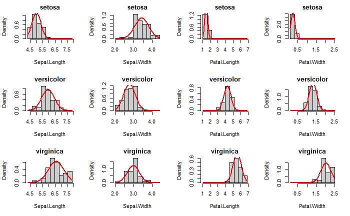

```r
par(mfcol=c(3,4))
for (k in 1:4) {
  j0 <- names(iris)[k]
  br0 <- seq(min(iris[,k]),max(iris[,k]),le=11)
  x0 <- seq(min(iris[,k]),max(iris[,k]),le=50)
  for (i in 1:3) {
    i0 <- levels(iris$Species)[i]
    x <- iris[iris$Species==i0,j0]
    hist(x,br=br0,proba=T,col=grey(0.8), main=i0,xlab=j0)
    lines(x0,dnorm(x0,mean(x),sd(x)),col="red",lwd=2)
  }
}
```

Approche bivariée : on réalise les analyses de la variance à 1 facteur, variable par variable. On prend par exemple la recherche d’une relation entre la longueur des sépales et les espèces.

Calcul des moyennes par groupe:

```r
tapply(iris$Sepal.Length, iris$Species, mean)
```

```
    setosa versicolor  virginica
     5.006      5.936      6.588
```

Les écarts par groupe:

```r
tapply(iris$Sepal.Length,iris$Species,sd)
```

```
    setosa versicolor  virginica
 0.3524897  0.5161711  0.6358796
```

l’analyse de la variance à 1 facteur

```r
options(show.signif.stars=FALSE)
anova(lm(iris$Sepal.Length~iris$Species))
```

```
Analysis of Variance Table

Response: iris$Sepal.Length
              Df Sum Sq Mean Sq F value    Pr(>F)
iris$Species   2 63.212  31.606  119.26 < 2.2e-16
Residuals    147 38.956   0.265
```

Approche bivariée : on représente tous les nuages bivariés.

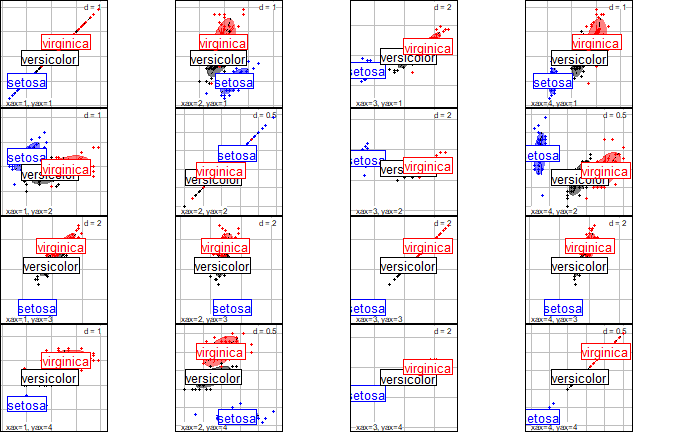

```r
# install.packages("ade4")
library(ade4)
# install.packages(("adegraphics"))
library(adegraphics)
s.class(iris[,1:4], iris$Species, xax=1:4, yax=1:4, porigin.include=FALSE,
plabels.cex=1.5, col=c("blue","black","red"), ppoints.cex=1, starSize=0.5)
```

Approche en dimension 3 : on peut encore visualiser en trois dimensions.

```r
# install.packages("scatterplot3d")
library(scatterplot3d)
par(mfrow=c(2,2))
mar0=c(2,3,2,3)
scatterplot3d(iris[,1],iris[,2],iris[,3],mar=mar0,color=c("blue","black",
"red")[iris$Species],pch=19)
scatterplot3d(iris[,2],iris[,3],iris[,4],mar=mar0,color=c("blue","black",
"red")[iris$Species],pch=19)
```

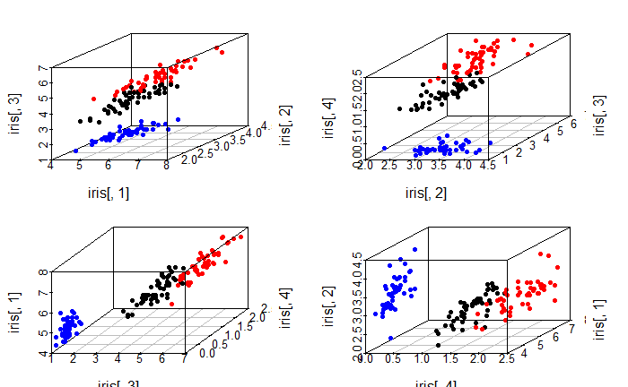

```r
scatterplot3d(iris[,3],iris[,4],iris[,1],mar=mar0,color=c("blue","black",
"red")[iris$Species],pch=19)
scatterplot3d(iris[,4],iris[,1],iris[,2],mar=mar0,color=c("blue","black",
"red")[iris$Species],pch=19)
```

La variable discriminante

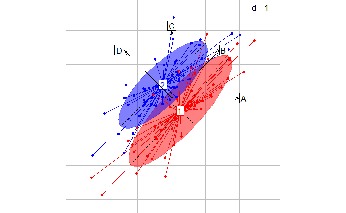

```r
set.seed(24122006)
library(MASS)
s <- matrix(c(1, 0.8, 0.8, 1), 2)
x1 <- mvrnorm(50, c(0.3, -0.3), s)
x2 <- mvrnorm(50, c(-0.3, 0.3), s)
x <- rbind.data.frame(x1, x2)
x <-scalewt(x,scale=F)
fac <- factor(rep(1:2, rep(50, 2)))
s.class(x,fac,col=c("red","blue"))
art <- matrix(c(2, 0, sqrt(2), sqrt(2), 0, 2, -sqrt(2),sqrt(2)), byrow=TRUE, nrow=4)
s.arrow(art, labels=c("A","B","C","D"), add=TRUE)
```

```r
par(mfrow=c(2,2))
f1 <- function(a,b,cha) {
z <- a*x[,1]+b*x[,2]
z0 <- seq(-4,4,le=50)
z1 <- z[fac==1]
z2 <- z[fac==2]
hist(z, proba = TRUE, col = grey(0.9),xlim=c(-4,4),main=cha)
lines(z0,dnorm(z0,mean(z),sd(z)),lwd=2)
lines(z0,0.5*dnorm(z0,mean(z1),sd(z1)),col="red",lwd=2)
lines(z0,0.5*dnorm(z0,mean(z2),sd(z2)),col="blue",lwd=2)
}
f1(1,0,"A")
f1(1/sqrt(2),1/sqrt(2),"B")
```

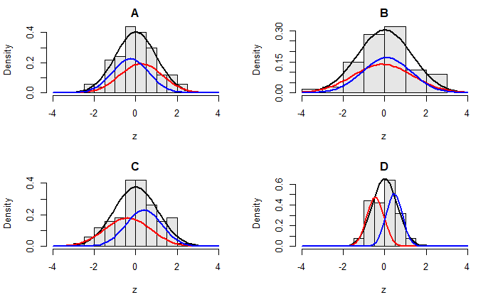

```r
f1(0,1,"C")
f1(-1/sqrt(2),1/sqrt(2),"D")
```

```r
f2 <- function(a,b) {
z <- a*x[,1]+b*x[,2]
a1 <- var(z)*99/100
a2 <- var(predict(lm(z~fac)))*99/100
a3 <- a2/a1
round(c(a1,a2,a3),3)
}
f2(1,0)
```

```
[1] 0.966 0.066 0.068
```

```r
f2(1/sqrt(2),1/sqrt(2))
```

```
[1] 1.716 0.009 0.005
```

```r
f2(0,1)
```

```
[1] 1.118 0.151 0.135
```

```r
f2(-1/sqrt(2),1/sqrt(2))
```

```
[1] 0.368 0.208 0.564
```

Interprétations des valeurs ci-dessus:La premiere quantite est la variance descriptive totale. La deuxieme quantite est la variance intergroupe. La derniere est le rapport de la variance intergroupe sur la variance totale. La premiere quantite ne peut pas exceder la premiere valeur propre de l’ACP centree et ne peut pas etre moindre que la seconde valeur propre.

```r
w <- dudi.pca(x,scal=F,scannf=F)
w$eig
```

```
[1] 1.7203606 0.3640783
```

```r
w$c1
```

|  | CS1 | CS2 |
| --- | --- | --- |
| V1 | 0.6664220 | -0.7455748 |
| V2 | 0.7455748 | 0.6664220 |

La position B est presque celle qui maximise la variance (elle est en fait l’axe principal theorique) : toute la variabilite est intra-population. La position D est presque celle qui minimise la variance (elle est en fait le second axe principal theorique). On y trouve quatre fois moins de variance mais la variabilite y est pour moitie inter-groupe.

L’analyse inter-classe cherche les axes sur la base de la variabilite inter-classe :

```r
wbet <- bca(w, fac, scannf=F)
wbet$eig
```

```
[1] 0.216294
```

```r
wbet$c1
```

|  | CS1 |
| --- | --- |
| V1 | -0.5512509 |
| V2 | 0.8343395 |

```r
NA
```

La position D est presque celle qui maximise la variance inter-classe (elle est en fait l’axe inter-classe theorique) : on ne peut pas trouver plus de variance inter-groupe.

L’analyse discriminante est celle qui maximisera le rapport :

```r
wdis <- discrimin(w,fac,scannf=F)
wdis$fa/sqrt(sum(wdis$fa^2))
```

|  | DS1 |
| --- | --- |
| V1 | -0.7073308 |
| V2 | 0.7068827 |

```r
NA
```

```r
wdis$eig
```

```
[1] 0.5637036
```

[…] On commence toujours par caractériser la valeur discriminante de chacune des variables:

```r
apply(iris[,1:4],2,function(x) summary (lm(x~iris[,5])))
```

```
$Sepal.Length

Call:
lm(formula = x ~ iris[, 5])

Residuals:
    Min      1Q  Median      3Q     Max
-1.6880 -0.3285 -0.0060  0.3120  1.3120

Coefficients:
                    Estimate Std. Error t value Pr(>|t|)
(Intercept)           5.0060     0.0728  68.762  < 2e-16
iris[, 5]versicolor   0.9300     0.1030   9.033 8.77e-16
iris[, 5]virginica    1.5820     0.1030  15.366  < 2e-16

Residual standard error: 0.5148 on 147 degrees of freedom
Multiple R-squared:  0.6187,    Adjusted R-squared:  0.6135
F-statistic: 119.3 on 2 and 147 DF,  p-value: < 2.2e-16


$Sepal.Width

Call:
lm(formula = x ~ iris[, 5])

Residuals:
   Min     1Q Median     3Q    Max
-1.128 -0.228  0.026  0.226  0.972

Coefficients:
                    Estimate Std. Error t value Pr(>|t|)
(Intercept)          3.42800    0.04804  71.359  < 2e-16
iris[, 5]versicolor -0.65800    0.06794  -9.685  < 2e-16
iris[, 5]virginica  -0.45400    0.06794  -6.683 4.54e-10

Residual standard error: 0.3397 on 147 degrees of freedom
Multiple R-squared:  0.4008,    Adjusted R-squared:  0.3926
F-statistic: 49.16 on 2 and 147 DF,  p-value: < 2.2e-16


```

[output cut: 23 more lines]

```
lm(formula = x ~ iris[, 5])

Residuals:
   Min     1Q Median     3Q    Max
-0.626 -0.126 -0.026  0.154  0.474

Coefficients:
                    Estimate Std. Error t value Pr(>|t|)
(Intercept)          0.24600    0.02894    8.50 1.96e-14
iris[, 5]versicolor  1.08000    0.04093   26.39  < 2e-16
iris[, 5]virginica   1.78000    0.04093   43.49  < 2e-16

Residual standard error: 0.2047 on 147 degrees of freedom
Multiple R-squared:  0.9289,    Adjusted R-squared:  0.9279
F-statistic:   960 on 2 and 147 DF,  p-value: < 2.2e-16
```

[…] Comparaison de deux fonctions

```r
lda1 <- lda(as.matrix(iris[,1:4]),iris$Species)
lda1
```

```
Call:
lda(as.matrix(iris[, 1:4]), grouping = iris$Species)

Prior probabilities of groups:
    setosa versicolor  virginica
 0.3333333  0.3333333  0.3333333

Group means:
           Sepal.Length Sepal.Width Petal.Length Petal.Width
setosa            5.006       3.428        1.462       0.246
versicolor        5.936       2.770        4.260       1.326
virginica         6.588       2.974        5.552       2.026

Coefficients of linear discriminants:
                    LD1         LD2
Sepal.Length  0.8293776  0.02410215
Sepal.Width   1.5344731  2.16452123
Petal.Length -2.2012117 -0.93192121
Petal.Width  -2.8104603  2.83918785

Proportion of trace:
   LD1    LD2
0.9912 0.0088
```

Utiliser discrimin et consulter la documentation (dans ade4) :

```r
dis1 <- discrimin(dudi.pca(iris[,1:4],scan=F),iris$Species,scan=F)
dis1
```

```
Discriminant analysis
call: discrimin(dudi = dudi.pca(iris[, 1:4], scan = F), fac = iris$Species,
    scannf = F)
class: discrimin

$nf (axis saved) : 2

eigen values: 0.9699 0.222

  data.frame nrow ncol content
1 $fa        4    2    loadings / canonical weights
2 $li        150  2    canonical scores
3 $va        4    2    cos(variables, canonical scores)
4 $cp        4    2    cos(components, canonical scores)
5 $gc        3    2    class scores
```

Sans en avoir l’air, les deux fonctions sont coherentes. La premiere donne une combinaison lineaire de variables de depart avec les coecients qui sont dans la colonne LD1. Calculer cette combinaison :

```r
w1 <- as.vector(as.matrix(iris[,1:4])%*%lda1$scaling[,1])
w1[1:10]
```

```
 [1] 5.956693 5.023581 5.384722 4.708094 6.027203 5.596840 5.107511 5.500187 4.455445 5.237953
```

La seconde donne une combinaison lineaire de variables normalisees (en 1=n) avec les coecients qui sont dans la composante fa (fa pour facteur, dans le vocabulaire du schema de dualite). Calculer cette combinaison et comparer :

```r
w2 <- as.vector(scalewt(iris[,1:4])%*%dis1$fa[,1])

w2[1:10]
```

```
 [1] 1.413522 1.249914 1.313235 1.194598 1.425885 1.350427 1.264630 1.333481 1.150300 1.287502
```

```r
w2[141:150]
```

```
 [1] -1.1665246 -0.8951876 -0.9656587 -1.1915858 -1.2005876 -0.9897715 -0.9081633 -0.8710231 -1.0320523 -0.8211248
```

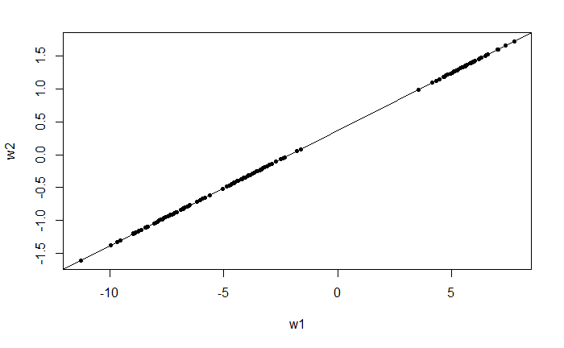

```r
plot(w1,w2,pch=20)
abline(lm(w2~w1))
```

La seconde donne une combinaison lineaire de variance totale 1 (en 1=n) :

```r
var(w2)*149/150
```

```
[1] 1
```

qui maximise la variance inter-classe (la premiere valeur propre) :

```r
dis1$eig
```

```
[1] 0.9698722 0.2220266
```

```r
summary(lm(w2 ~ iris[, 5]))$r.squared
```

```
[1] 0.9698722
```

ou encore

```r
var(predict(lm(w2~iris[,5])))*149/150
```

```
[1] 0.9698722
```

La premiere donne une combinaison lineaire de variance intra-classe unite :

```r
tapply(w1,iris[,5],var)
```

```
    setosa versicolor  virginica
 0.7181898  1.0736485  1.2081617
```

```r
mean(tapply(w1,iris[,5],var))
```

```
[1] 1
```

qui maximise la variance inter-classe.

Tester les valeurs propres

[..]

Les valeurs propres de discrimin sont :

```r
w1 <- dis1$eig
w1
```

```
[1] 0.9698722 0.2220266
```

Les valeurs propres de l’autre diagonalisation sont donc :

```r
w2 <- w1/(1-w1)
w2
```

```
[1] 32.191929  0.285391
```

```r
w2/sum(w2)
```

```
[1] 0.991212605 0.008787395
```

[….] Test de Pillai

```r
size <- as.matrix(iris[,1:4])
spec <- iris[,5]
m1 <- manova(size~spec)
summary(m1,test="Pillai")
```

```
           Df Pillai approx F num Df den Df    Pr(>F)
spec        2 1.1919   53.466      8    290 < 2.2e-16
Residuals 147
```

Le critere de Pillai est la somme des valeurs propres de l’analyse discriminante du schema [1] :

```r
w1 <- dis1$eig
sum(w1)
```

```
[1] 1.191899
```

Test de Wilks

```r
summary(m1,test="Wilks")
```

```
           Df    Wilks approx F num Df den Df    Pr(>F)
spec        2 0.023439   199.15      8    288 < 2.2e-16
Residuals 147
```

Le critere de Wilks est le produit des pourcentages de variance intra-classes qu’on teste avec log(W) :

```r
prod(1-w1)
```

```
[1] 0.02343863
```

Test de Hotelling-Lawley

```r
summary(m1,test="Hotelling-Lawley")
```

```
           Df Hotelling-Lawley approx F num Df den Df    Pr(>F)
spec        2           32.477   580.53      8    286 < 2.2e-16
Residuals 147
```

Le critere de Hotelling-Lawley est la somme des valeurs propres de l’analyse discriminante du second schema :

```r
w2 <- w1/(1-w1)
w2
```

```
[1] 32.191929  0.285391
```

```r
sum(w2)
```

```
[1] 32.47732
```

Le test de Roy

```r
summary(m1,test="Roy")
```

```
           Df    Roy approx F num Df den Df    Pr(>F)
spec        2 32.192     1167      4    145 < 2.2e-16
Residuals 147
```

Le critere de Roy est la plus grande valeur propre du schema 2 :

```r
w2
```

```
[1] 32.191929  0.285391
```

Ces tests s’etendent aux modeles lineaires quelconques comme l’anova Quand l’hypothese de normalite est intenable, on a une version non parame- trique du test de Pillai avec randtest.discrimin.

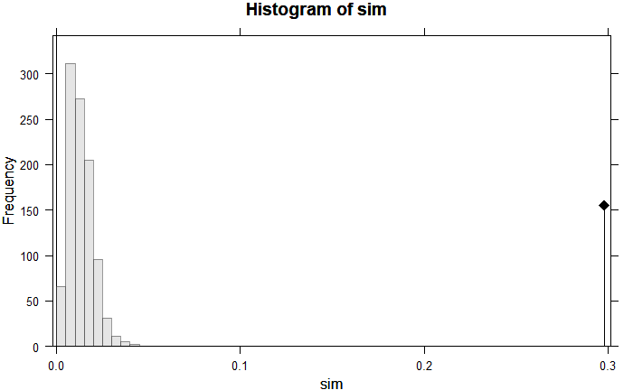

```r
plot(randtest(dis1))
```

La statistique observee est le critere de Pillai divise par le rang de l’analyse de depart :

```r
sum(dis1$eig)/4
```

```
[1] 0.2979747
```

Discrimination predictive ou descriptive

La fonction lda est centree sur la question de l’affectation d’un individu à une classe. Peut-on prédire à quelle classe appartient un individu dont on connaît les mesures ?

Exemple des iris Le but de l’exercice est de diviser au hasard le tableau de donnees en deux parties, la première pour chercher une fonction discriminante, la seconde pour déterminer l’espèce à l’aide de cette fonction. On comparera ensuite le résultat obtenu et les vraies valeurs.

```r
echa <- sample(1:150,50)
tabref <- iris[echa,1:4] # selection de 50 iris
espref <- iris[echa,5] # noms d'especes de la selection
tabsup <- iris[-echa,1:4] # tableau des 100 autres
espsup <- iris[-echa,5] # nom de l'espece des 100 autres
lda2 <- lda(tabref,espref)
lda2
```

```
Call:
lda(tabref, espref)

Prior probabilities of groups:
    setosa versicolor  virginica
      0.26       0.40       0.34

Group means:
           Sepal.Length Sepal.Width Petal.Length Petal.Width
setosa         5.030769    3.407692     1.461538   0.2846154
versicolor     5.995000    2.875000     4.260000   1.3450000
virginica      6.523529    2.923529     5.488235   2.0411765

Coefficients of linear discriminants:
                    LD1        LD2
Sepal.Length  0.7957829 -1.1718795
Sepal.Width   3.0171267 -0.7415411
Petal.Length -2.0348545  2.7044654
Petal.Width  -4.0047667 -5.5383953

Proportion of trace:
  LD1   LD2
0.992 0.008
```

```r
espestim <- predict(lda2,tabsup)$class # fonction generique utilise predict.lda
table(espestim,espsup)
```

```
            espsup
espestim     setosa versicolor virginica
  setosa         37          0         0
  versicolor      0         27         2
  virginica       0          3        31
```

A l’aide de 50 plantes, on récupère pratiquement sans erreur le nom des 100 inconnues. Le cas est très favorable.

NB: ne faites pas l’exercie sur les crânes dans le cours / tp svp.